# Programming Assignment - Part 4

## Simulation Study Results

```python
import simstudy4
```

```python
simstudy4.task_4_2_1()
```

```
First test series:
Mean = 0.0
Var = 25.002500250025
Name: test sequence
Lag = 0; covariance = 25.0; correlation = 0.9999
Lag = 1; covariance = -25.0; correlation = -0.9999
____________________________________________
Second test series:
Mean = 0.5
Var = 14.750737536876844
Name: test sequence
Lag = 0; covariance = 14.75; correlation = 0.99995
Lag = 1; covariance = -12.25; correlation = -0.8304669491525424
Lag = 2; covariance = 9.75; correlation = 0.6609838983050847
Lag = 3; covariance = -12.25; correlation = -0.8304669491525424
```

```
_____________________________________________________
NEW RUN with rho=0.01
_____________________________________________________

Name: wt, Mean: 0.6994779941341437, Variance: 123.8254911431852
Name: ql, Mean: 0.00010268336953889229, Variance: 0.0001106023323377446
Name: bs, Mean: 0.009715041297219347, Variance: 0.009623936061117102
Name: waiting time with lags 1 to 20
Lag = 0; covariance = 123.74114135357814; correlation = 0.9993188010899183
Lag = 1; covariance = 15.688291005289265; correlation = 0.1266967799638942
Lag = 2; covariance = -0.48926946427792517; correlation = -0.003951282242136718
Lag = 3; covariance = -0.48926946427792517; correlation = -0.003951282242136718
Lag = 4; covariance = -0.48926946427792517; correlation = -0.003951282242136718
Lag = 5; covariance = -0.48926946427792517; correlation = -0.003951282242136718
Lag = 6; covariance = -0.48926946427792517; correlation = -0.003951282242136718
Lag = 7; covariance = -0.48926946427792517; correlation = -0.003951282242136718
Lag = 8; covariance = -0.48926946427792517; correlation = -0.003951282242136718
Lag = 9; covariance = -0.48926946427792517; correlation = -0.003951282242136718
Lag = 10; covariance = -0.48926946427792517; correlation = -0.003951282242136718
Lag = 11; covariance = -0.48926946427792517; correlation = -0.003951282242136718
Lag = 12; covariance = -0.48926946427792517; correlation = -0.003951282242136718
Lag = 13; covariance = -0.48926946427792517; correlation = -0.003951282242136718
Lag = 14; covariance = -0.48926946427792517; correlation = -0.003951282242136718
Lag = 15; covariance = -0.48926946427792517; correlation = -0.003951282242136718
Lag = 16; covariance = -0.48926946427792517; correlation = -0.003951282242136718
Lag = 17; covariance = -0.48926946427792517; correlation = -0.003951282242136718
Lag = 18; covariance = -0.48926946427792517; correlation = -0.003951282242136718
Lag = 19; covariance = -0.48926946427792517; correlation = -0.003951282242136718
Lag = 20; covariance = -0.48926946427792517; correlation = -0.003951282242136718
Name: accumulated iat with lags 1 to 10
Lag = 0; covariance = 45636505.05397884; correlation = 0.9993183367416497
Lag = 1; covariance = 287531.84190809727; correlation = 0.006296184198943412
Lag = 2; covariance = 1644583.218309842; correlation = 0.03601200758933521
Lag = 3; covariance = 390870.649268955; correlation = 0.008559029808408298
Lag = 4; covariance = 2203961.821316071; correlation = 0.04826091434728853
Lag = 5; covariance = -88224.06926226616; correlation = -0.0019318729611627285
Lag = 6; covariance = -539310.1254365146; correlation = -0.011809460362963537
Lag = 7; covariance = -199119.82156524807; correlation = -0.004360195607957259
Lag = 8; covariance = -363953.8872335255; correlation = -0.007969624159665022
Lag = 9; covariance = -513175.03785540164; correlation = -0.01123717131012604
Lag = 10; covariance = -1728169.7747223526; correlation = -0.03784233132752054
Name: inter-arrival time vs. waiting time; covariance = -5850.8861522155985; correlation = -0.037157150143908795
Name: inter-arrival time vs. service time; covariance = 31146.846384122502; correlation = 0.03313693132534046
Name: inter-arrival time vs. system time; covariance = 25295.960231906734; correlation = 0.0266480380094377
Name: service time vs. system time; covariance = 4391.2501759168545; correlation = 0.9854824568256935
Name: wt user 1 vs. wt user 2; covariance = -0.49804633140686094; correlation = -0.004164651510004781
```

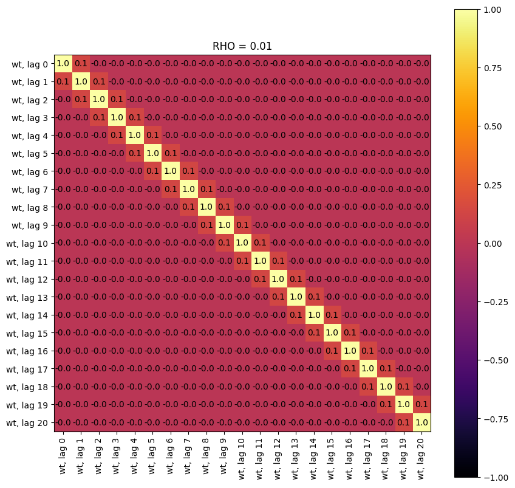

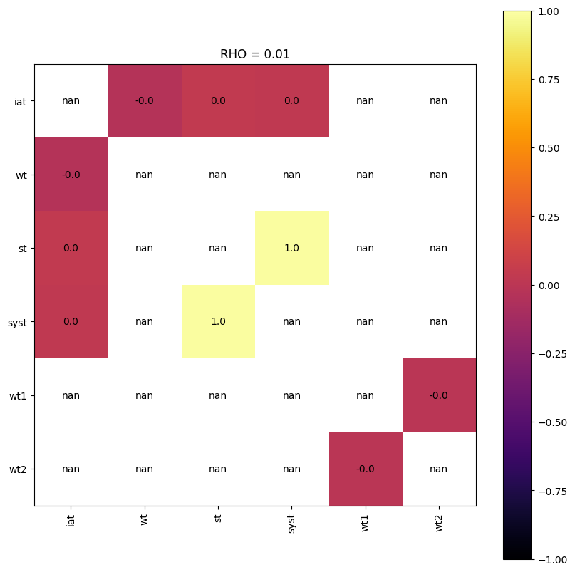

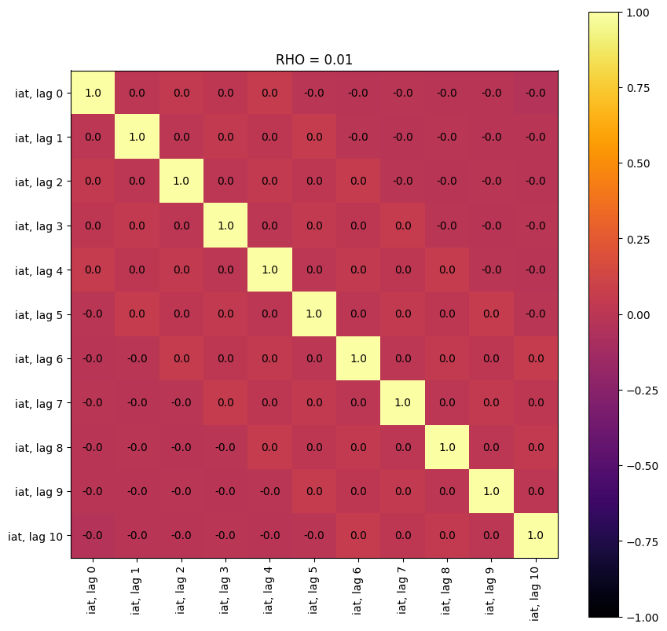

```
_____________________________________________________
NEW RUN with rho=0.5
_____________________________________________________

Name: wt, Mean: 66.89278003115692, Variance: 13788.974250174915
Name: ql, Mean: 0.4992408852065334, Variance: 1.2988935390328673
Name: bs, Mean: 0.4965210290530804, Variance: 0.24998957153117174
Name: waiting time with lags 1 to 20
Lag = 0; covariance = 13788.789493106993; correlation = 0.9999866011013894
Lag = 1; covariance = 10807.116175654146; correlation = 0.7837505516784221
Lag = 2; covariance = 8632.701901122673; correlation = 0.6260583089429705
Lag = 3; covariance = 6994.020472424636; correlation = 0.5072183286103327
Lag = 4; covariance = 5755.910273817559; correlation = 0.41742845909981624
Lag = 5; covariance = 4785.293356574406; correlation = 0.3470376599270032
Lag = 6; covariance = 4001.7530903871702; correlation = 0.29021397950151423
Lag = 7; covariance = 3349.5342443554273; correlation = 0.24291395310372255
Lag = 8; covariance = 2799.1059779550724; correlation = 0.20299595366345435
Lag = 9; covariance = 2365.688397165013; correlation = 0.1715637693017669
Lag = 10; covariance = 2014.881772993076; correlation = 0.14612267282807617
Lag = 11; covariance = 1697.5181704821625; correlation = 0.12310692149277379
Lag = 12; covariance = 1435.0329610431163; correlation = 0.1040710450978551
Lag = 13; covariance = 1224.3452854824427; correlation = 0.08879161446449954
Lag = 14; covariance = 1020.0080551524434; correlation = 0.07397272898232474
Lag = 15; covariance = 848.3740386705003; correlation = 0.06152553651042887
Lag = 16; covariance = 679.7600072971791; correlation = 0.04929735852458759
Lag = 17; covariance = 527.2203056877397; correlation = 0.03823491842992251
Lag = 18; covariance = 414.4476719933464; correlation = 0.0300564541258817
Lag = 19; covariance = 323.8143715945225; correlation = 0.02348357214391164
Lag = 20; covariance = 254.89614035098202; correlation = 0.01848550412281382
Name: accumulated iat with lags 1 to 10
Lag = 0; covariance = 17931.37481453172; correlation = 0.9999866011013896
Lag = 1; covariance = 27.60014354568193; correlation = 0.0015391889366893313
Lag = 2; covariance = 112.53365135058266; correlation = 0.0062757119678520734
Lag = 3; covariance = 68.70252455344598; correlation = 0.0038313628891192956
Lag = 4; covariance = -74.80068152397143; correlation = -0.0041714414009463175
Lag = 5; covariance = -90.86260301015136; correlation = -0.005067173403665145
Lag = 6; covariance = 12.87679858521733; correlation = 0.0007181059000486314
Lag = 7; covariance = 79.31261413994434; correlation = 0.004423060264960515
Lag = 8; covariance = -42.84480984041875; correlation = -0.002389344721768597
Lag = 9; covariance = -25.04876907592552; correlation = -0.00139690535216011
Lag = 10; covariance = 17.31477861269377; correlation = 0.0009656006186262329
Name: inter-arrival time vs. waiting time; covariance = -7007.357765651304; correlation = -0.22178541598862483
Name: inter-arrival time vs. service time; covariance = 46.36919395493533; correlation = 0.002588460427394233
Name: inter-arrival time vs. system time; covariance = -6960.988571696362; correlation = -0.1919124775621041
Name: service time vs. system time; covariance = 4408.249752635673; correlation = 0.4911578832876588
Name: wt user 1 vs. wt user 2; covariance = -81.71311254831107; correlation = -0.005930645138846582
```

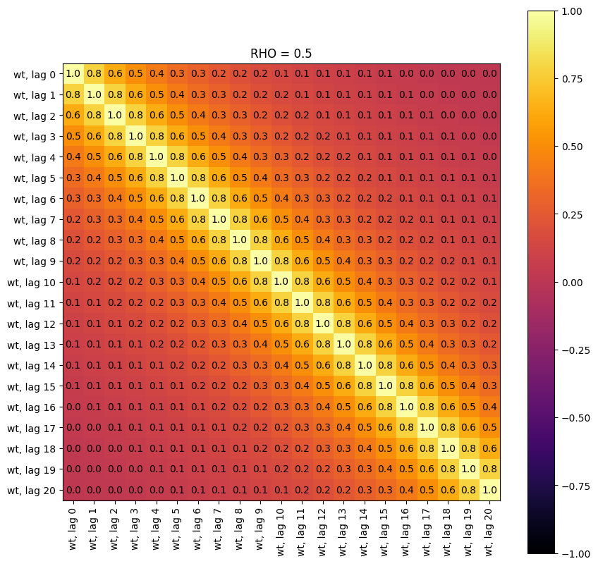

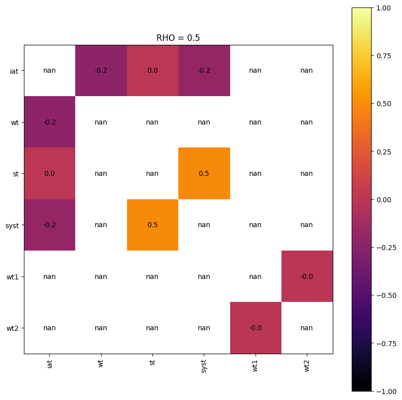

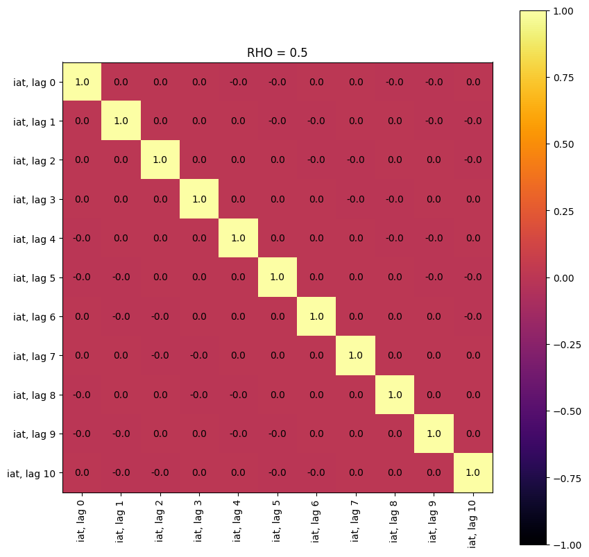

```
_____________________________________________________
NEW RUN with rho=0.8
_____________________________________________________

Name: wt, Mean: 263.8293502196158, Variance: 113307.96735943202
Name: ql, Mean: 3.1606643983521874, Variance: 19.598768718357054
Name: bs, Mean: 0.7968441965702674, Variance: 0.1618841986089392
Name: waiting time with lags 1 to 20
Lag = 0; covariance = 113307.02152633636; correlation = 0.9999916525455562
Lag = 1; covariance = 109401.82766988882; correlation = 0.965526345758615
Lag = 2; covariance = 105873.42182402585; correlation = 0.9343863833350524
Lag = 3; covariance = 102612.12083024142; correlation = 0.9056037560424893
Lag = 4; covariance = 99531.84891433736; correlation = 0.8784188017300276
Lag = 5; covariance = 96640.60282670973; correlation = 0.8529020957559799
Lag = 6; covariance = 93913.51424613618; correlation = 0.8288341626341831
Lag = 7; covariance = 91317.51223751619; correlation = 0.8059231346710298
Lag = 8; covariance = 88827.55654775591; correlation = 0.7839480189948153
Lag = 9; covariance = 86454.40175697881; correlation = 0.7630037302031095
Lag = 10; covariance = 84209.33080405001; correlation = 0.7431898459260485
Lag = 11; covariance = 82052.30322840766; correlation = 0.7241529888902154
Lag = 12; covariance = 79965.22505587559; correlation = 0.7057334706412338
Lag = 13; covariance = 77985.5069154538; correlation = 0.6882614588616757
Lag = 14; covariance = 76077.04789264353; correlation = 0.6714183447604728
Lag = 15; covariance = 74246.43493476509; correlation = 0.655262261472248
Lag = 16; covariance = 72480.85769956054; correlation = 0.6396801512610231
Lag = 17; covariance = 70772.76267296895; correlation = 0.6246053505528503
Lag = 18; covariance = 69122.83720856856; correlation = 0.610043925589974
Lag = 19; covariance = 67510.57662256366; correlation = 0.5958149121889081
Lag = 20; covariance = 65961.73111497874; correlation = 0.5821455688613404
Name: accumulated iat with lags 1 to 10
Lag = 0; covariance = 6943.103756274335; correlation = 0.9999916527545911
Lag = 1; covariance = -4.242312560897517; correlation = -0.0006110058697365447
Lag = 2; covariance = 5.321106661565864; correlation = 0.000766380920085514
Lag = 3; covariance = 10.014394026456102; correlation = 0.0014423391591695319
Lag = 4; covariance = -4.06585119600004; correlation = -0.0005855907386762178
Lag = 5; covariance = -32.260528026694374; correlation = -0.004646374283402723
Lag = 6; covariance = -2.521366216383285; correlation = -0.00036314381268495743
Lag = 7; covariance = 23.07382762859379; correlation = 0.003323245026381883
Lag = 8; covariance = -17.029255868155815; correlation = -0.002452665885251838
Lag = 9; covariance = -16.57255422581602; correlation = -0.0023868886988276253
Lag = 10; covariance = 0.9182492226709655; correlation = 0.00013225231683878583
Name: inter-arrival time vs. waiting time; covariance = -8031.994818493724; correlation = -0.1425483310560265
Name: inter-arrival time vs. service time; covariance = 52.21971814771132; correlation = 0.004704849382511
Name: inter-arrival time vs. system time; covariance = -7979.775100346007; correlation = -0.13888795173283347
Name: service time vs. system time; covariance = 4450.341078306254; correlation = 0.19554221779582112
Name: wt user 1 vs. wt user 2; covariance = 1589.5208930643712; correlation = 0.014016697027180848
```

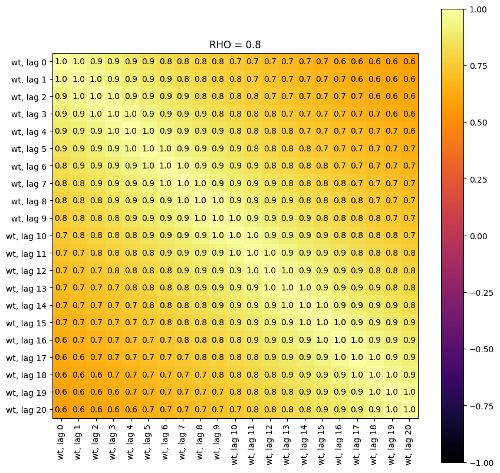

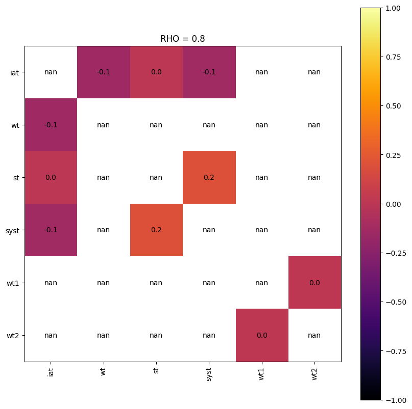

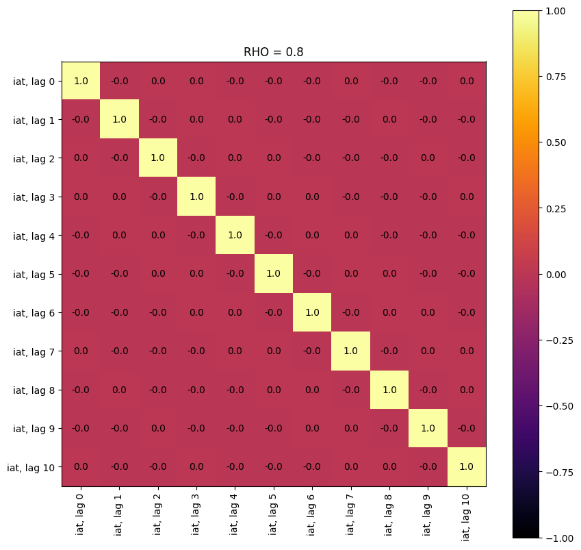

```
_____________________________________________________
NEW RUN with rho=0.95
_____________________________________________________

Name: wt, Mean: 1137.694463736775, Variance: 1375897.6408542648
Name: ql, Mean: 16.1693295159354, Variance: 294.97563366939755
Name: bs, Mean: 0.9441545019149405, Variance: 0.05272696392307432
Name: waiting time with lags 1 to 20
Lag = 0; covariance = 1375887.9595474668; correlation = 0.9999929636431443
Lag = 1; covariance = 1371608.6675842141; correlation = 0.9968827817253995
Lag = 2; covariance = 1367441.1520319895; correlation = 0.99385383870778
Lag = 3; covariance = 1363365.0773190146; correlation = 0.9908913547322684
Lag = 4; covariance = 1359334.0796926273; correlation = 0.987961632704484
Lag = 5; covariance = 1355367.7881299274; correlation = 0.9850789389306671
Lag = 6; covariance = 1351446.2772947692; correlation = 0.982228791711341
Lag = 7; covariance = 1347543.4719535124; correlation = 0.9793922396122811
Lag = 8; covariance = 1343703.0774977496; correlation = 0.9766010476356901
Lag = 9; covariance = 1339897.572047819; correlation = 0.9738352129275444
Lag = 10; covariance = 1336125.1326600164; correlation = 0.9710934105755465
Lag = 11; covariance = 1332404.4816276575; correlation = 0.9683892479097476
Lag = 12; covariance = 1328694.353579187; correlation = 0.9656927333302423
Lag = 13; covariance = 1325014.743853452; correlation = 0.9630183994143483
Lag = 14; covariance = 1321358.125584474; correlation = 0.9603607756490313
Lag = 15; covariance = 1317758.597335891; correlation = 0.9577446448107314
Lag = 16; covariance = 1314191.6962378204; correlation = 0.9551522273283843
Lag = 17; covariance = 1310664.2558923014; correlation = 0.9525884898520057
Lag = 18; covariance = 1307143.8755321577; correlation = 0.9500298835606554
Lag = 19; covariance = 1303635.6236845783; correlation = 0.9474800922510336
Lag = 20; covariance = 1300151.9637368482; correlation = 0.9449481742912301
Name: accumulated iat with lags 1 to 10
Lag = 0; covariance = 4937.2326226997975; correlation = 0.999992964187715
Lag = 1; covariance = -3.2837886857842022; correlation = -0.000665102463790289
Lag = 2; covariance = 6.2753007926448845; correlation = 0.0012710068818622962
Lag = 3; covariance = 6.370697213288622; correlation = 0.0012903285862952269
Lag = 4; covariance = -6.2908797663385485; correlation = -0.001274162265712614
Lag = 5; covariance = -19.565686906452356; correlation = -0.003962857483359401
Lag = 6; covariance = -2.3757206327618405; correlation = -0.0004811812809294643
Lag = 7; covariance = 14.590070603961976; correlation = 0.002955090243041017
Lag = 8; covariance = -12.850701871840101; correlation = -0.0026027964324854876
Lag = 9; covariance = -1.8372536307733753; correlation = -0.0003721195342821546
Lag = 10; covariance = 2.91834629575078; correlation = 0.0005910853277191242
Name: inter-arrival time vs. waiting time; covariance = -8703.060242998035; correlation = -0.05256202562441848
Name: inter-arrival time vs. service time; covariance = 25.16170100108684; correlation = 0.0026816697396737435
Name: inter-arrival time vs. system time; covariance = -8677.898541996983; correlation = -0.05232677804985397
Name: service time vs. system time; covariance = 4400.756099130638; correlation = 0.05635282418713806
Name: wt user 1 vs. wt user 2; covariance = 873060.5371838051; correlation = 0.6352453353591813
```

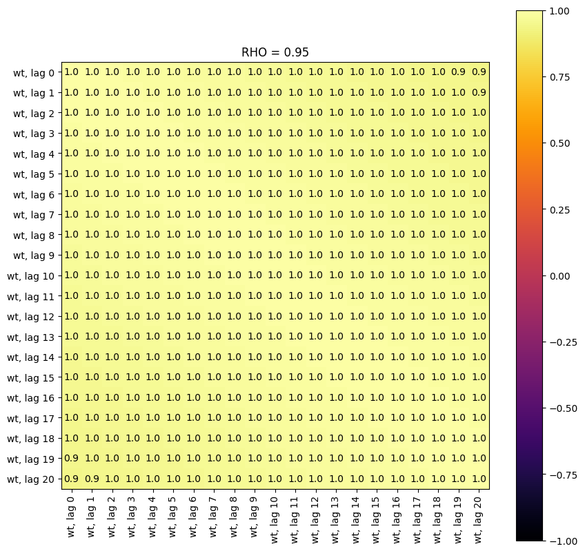

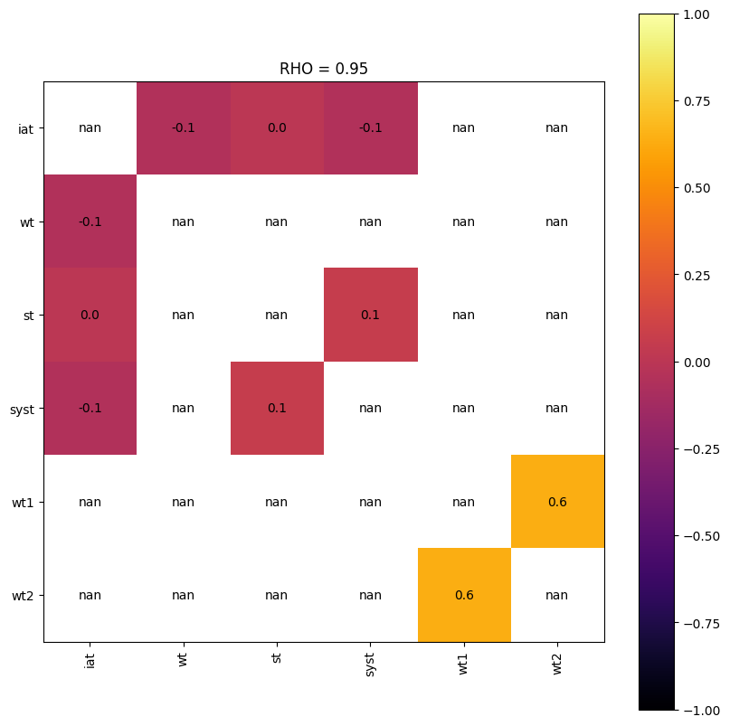

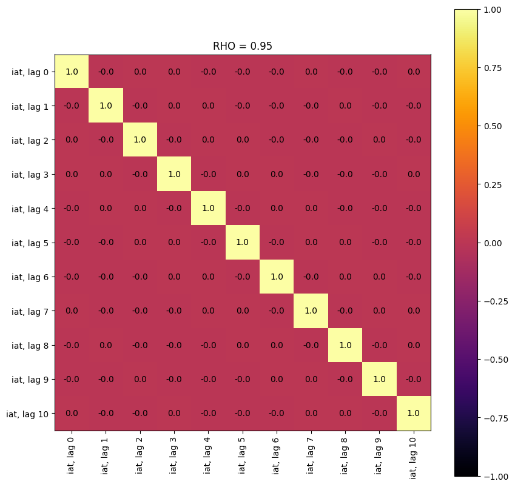

```python
simstudy4.task_4_3_1()
```

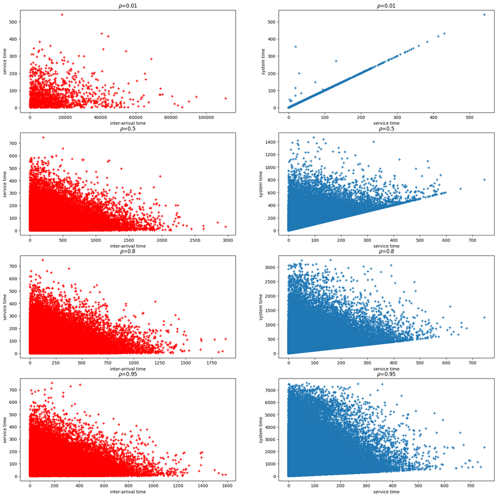

```python
simstudy4.task_4_3_2()
```

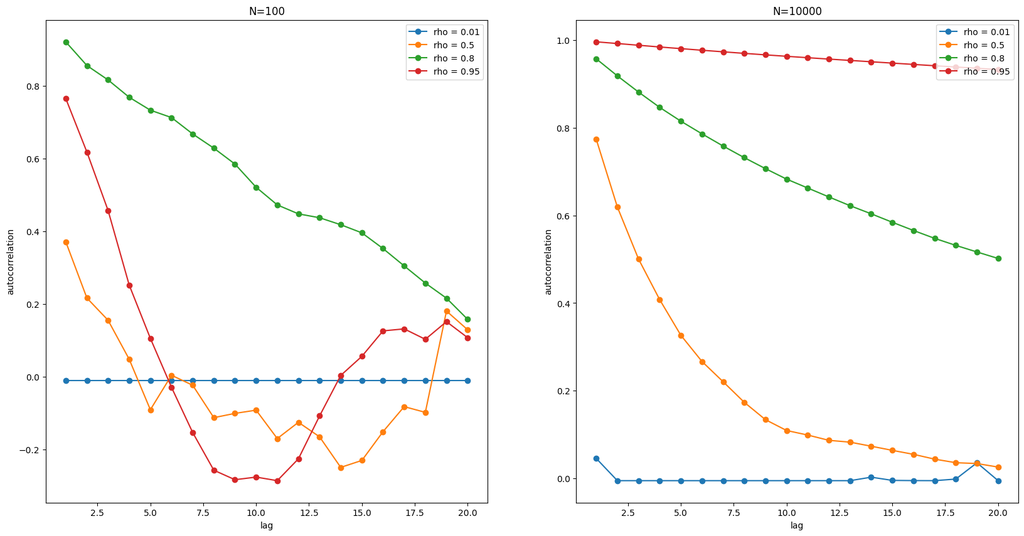

```python
simstudy4.task_4_3_3()
```

[output not shown]

## Answers to "Analysis and General Questions"

##### 4.4.1: Lag Size

For the first test series, lag sizes of 0 and 1 are reasonable; for the second series, you should choose lag sizes between 0 and 3. Since the series repeats after 2 or 4 elements, the results for higher numbers don't give you any new information. The autocorrelation with lag 0 is always close to 1, the covariance is not scaled version, so if values are higher (e.g., 5 and -5 in the first time series), their covariance is also higher than 1. In addition, for the first time serives, the autocorrelation with lag 1 is close to -1, since neigbring values are opposite in sign. In the second time series, the correlations with lag 1 and 3 are negative, since the sign of the values in the list alternates at each time step. With lag 2, the correlation is positive, because the corresponding pairs conside in sign.

##### 4.4.2: Correlation Times in the DES

IAT (inter-arrival time) vs. WT (waiting time)  
Negative, however very small, correlation values indicate that in general when packets arrival in short intervals, they are more likely to wait longer.

IAT vs. ST (service time)  
Cross-correlation values for different offered traffic are all nearly zero, meaning that they are not correlated. This makes sense because IAT and ST are generated from independent random number sequences and therefore should not rely on each other.

IAT vs. SYST (system time)  
Since SYST is a combination of WT and ST, and considering IAT and ST are uncorrelated, the relation of IAT and SYST is similar to that of IAT and WT. The values are in most cases negative, indicating longer system time when packets arrive more frequently.

ST vs. SYST  
The correlation between system time and service time is high for low offered traffic values (packets don't have to wait, so the waiting time is basically 0). For higher offered traffic, the correlation becomes much lower.

WT1 vs. WT2  
For low offered traffic, the waiting times of two users are not correlated, since the packets are normally nor queued up. As the offered traffic increases, the waiting times become correlated, since they might wait in the same queue to be served by a single server.

The autocorrelation between the waiting times is high for large values of offered traffic. The interpretation is as follows: For a high offered traffic, there will be a high number of packets waiting in the queue from time to time. When the previous packet had to wait, the current packet will probably have to wait, too, since the server is slow compared to the arrival rate. On the other side, the offered traffic value is still below 1.0, thus the server is still quick enough to process all packets faster as they arrive (in the average!). Thus, the probablity is low, that a packet has to wait (at all or for a longer time) if the last packet has been served directly.

The autocorellation of IATs is close to zero for lags values different than 0. This is expected, since we generate inter-arrival times being independent from each other.

#### 4.4.3: Auto Correlation

The problem with N = 100 is, that in the transient phase of the simulation, the system does not behave as it does on the long run.

The correlation values are rather random, since for 100 packets, there will be no longer bursts or sparse times, when no packets arrive. Thus, the correlation between waiting times strongly depends on the random numbers and does not really show a clear behaviour. It is possible, that your plot looks quite different from this one due to the random behaviour.